# CS559: Project #1

Jerry Cheng

```python
import pandas as pd
import matplotlib.pyplot as plt
import numpy as np
import sklearn
```

```python
DF = pd.read_csv('S21_P1_trainset.csv')
pd.options.display.max_columns = None
```

## Exploratory Data Analysis

### Exploring the Data Structure.

First, we are going to look at the shape of the data and take a look at how the dataset looks like. We will also take some basic statistics of the dataset, to get a better idea of what the data set looks like.

```python
DF.shape
```

```
(200000, 201)
```

```python
DF.head(10)
```

|  | ID_code | var_0 | var_1 | var_2 | var_3 | var_4 | var_5 | var_6 | var_7 | var_8 | var_9 | var_10 | var_11 | var_12 | var_13 | var_14 | var_15 | var_16 | var_17 | var_18 | var_19 | var_20 | var_21 | var_22 | var_23 | var_24 | var_25 | var_26 | var_27 | … |
| --- | --- | --- | --- | --- | --- | --- | --- | --- | --- | --- | --- | --- | --- | --- | --- | --- | --- | --- | --- | --- | --- | --- | --- | --- | --- | --- | --- | --- | --- | --- |
| 0 | train_0 | 8.9255 | -6.7863 | 11.9081 | 5.0930 | 11.4607 | -9.2834 | 5.1187 | 18.6266 | -4.9200 | 5.7470 | 2.9252 | 3.1821 | 14.0137 | 0.5745 | 8.7989 | 14.5691 | 5.7487 | -7.2393 | 4.2840 | 30.7133 | 10.5350 | 16.2191 | 2.5791 | 2.4716 | 14.3831 | 13.4325 | -5.1488 | -0.4073 | … |
| 1 | train_1 | 11.5006 | -4.1473 | 13.8588 | 5.3890 | 12.3622 | 7.0433 | 5.6208 | 16.5338 | 3.1468 | 8.0851 | -0.4032 | 8.0585 | 14.0239 | 8.4135 | 5.4345 | 13.7003 | 13.8275 | -15.5849 | 7.8000 | 28.5708 | 3.4287 | 2.7407 | 8.5524 | 3.3716 | 6.9779 | 13.8910 | -11.7684 | -2.5586 | … |
| 2 | train_2 | 8.6093 | -2.7457 | 12.0805 | 7.8928 | 10.5825 | -9.0837 | 6.9427 | 14.6155 | -4.9193 | 5.9525 | -0.3249 | -11.2648 | 14.1929 | 7.3124 | 7.5244 | 14.6472 | 7.6782 | -1.7395 | 4.7011 | 20.4775 | 17.7559 | 18.1377 | 1.2145 | 3.5137 | 5.6777 | 13.2177 | -7.9940 | -2.9029 | … |
| 3 | train_3 | 11.0604 | -2.1518 | 8.9522 | 7.1957 | 12.5846 | -1.8361 | 5.8428 | 14.9250 | -5.8609 | 8.2450 | 2.3061 | 2.8102 | 13.8463 | 11.9704 | 6.4569 | 14.8372 | 10.7430 | -0.4299 | 15.9426 | 13.7257 | 20.3010 | 12.5579 | 6.8202 | 2.7229 | 12.1354 | 13.7367 | 0.8135 | -0.9059 | … |
| 4 | train_4 | 9.8369 | -1.4834 | 12.8746 | 6.6375 | 12.2772 | 2.4486 | 5.9405 | 19.2514 | 6.2654 | 7.6784 | -9.4458 | -12.1419 | 13.8481 | 7.8895 | 7.7894 | 15.0553 | 8.4871 | -3.0680 | 6.5263 | 11.3152 | 21.4246 | 18.9608 | 10.1102 | 2.7142 | 14.2080 | 13.5433 | 3.1736 | -3.3423 | … |
| 5 | train_5 | 11.4763 | -2.3182 | 12.6080 | 8.6264 | 10.9621 | 3.5609 | 4.5322 | 15.2255 | 3.5855 | 5.9790 | 0.8010 | -0.6192 | 13.6380 | 1.2589 | 8.1939 | 14.9894 | 12.0763 | -1.4710 | 6.7341 | 14.8241 | 19.7172 | 11.9882 | 1.0468 | 3.8663 | 4.7252 | 13.9427 | -1.2796 | -4.3763 | … |
| 6 | train_6 | 11.8091 | -0.0832 | 9.3494 | 4.2916 | 11.1355 | -8.0198 | 6.1961 | 12.0771 | -4.3781 | 7.9232 | -5.1288 | -7.5271 | 14.1629 | 13.3058 | 7.8412 | 14.3363 | 7.5951 | 11.0922 | 21.1976 | 6.2946 | 15.8877 | 24.2595 | 8.1159 | 3.9769 | 7.6851 | 13.3600 | -0.5156 | 0.0690 | … |
| 7 | train_7 | 13.5580 | -7.9881 | 13.8776 | 7.5985 | 8.6543 | 0.8310 | 5.6890 | 22.3262 | 5.0647 | 7.1971 | 1.4532 | -6.7033 | 14.2919 | 10.9699 | 6.9190 | 14.2459 | 9.5376 | -0.7226 | 5.1548 | 17.1535 | 13.7326 | 14.4195 | 1.2375 | 3.1711 | 9.1258 | 13.3250 | 3.3883 | -0.4418 | … |
| 8 | train_8 | 16.1071 | 2.4426 | 13.9307 | 5.6327 | 8.8014 | 6.1630 | 4.4514 | 10.1854 | -3.1882 | 9.0827 | 0.9501 | 1.7982 | 14.0654 | -3.0572 | 11.1642 | 14.8757 | 10.0075 | -8.9472 | 3.8349 | 0.8560 | 10.6958 | 6.3738 | 6.5580 | 2.6182 | 13.2506 | 13.7929 | -14.4918 | -2.5407 | … |
| 9 | train_9 | 12.5088 | 1.9743 | 8.8960 | 5.4508 | 13.6043 | -16.2859 | 6.0637 | 16.8410 | 0.1287 | 7.9682 | 0.8787 | 3.0537 | 13.9639 | 0.8071 | 9.9240 | 15.2659 | 11.3900 | 1.5367 | 5.4649 | 13.6196 | 23.7806 | 4.4221 | 6.1695 | 3.2978 | 4.5923 | 13.3778 | -3.2200 | -2.3302 | … |

```python
DF.info()
```

```
<class 'pandas.core.frame.DataFrame'>
RangeIndex: 200000 entries, 0 to 199999
Columns: 201 entries, ID_code to var_199
dtypes: float64(200), object(1)
memory usage: 306.7+ MB
```

```python
DF.describe()
```

|  | var_0 | var_1 | var_2 | var_3 | var_4 | var_5 | var_6 | var_7 | var_8 | var_9 | var_10 | var_11 | var_12 | var_13 | var_14 | var_15 | var_16 | var_17 | var_18 | var_19 | var_20 | var_21 | var_22 | var_23 | var_24 | var_25 | var_26 | var_27 | var_28 | … |
| --- | --- | --- | --- | --- | --- | --- | --- | --- | --- | --- | --- | --- | --- | --- | --- | --- | --- | --- | --- | --- | --- | --- | --- | --- | --- | --- | --- | --- | --- | --- |
| count | 200000.000000 | 200000.000000 | 200000.000000 | 200000.000000 | 200000.000000 | 200000.000000 | 200000.000000 | 200000.000000 | 200000.000000 | 200000.000000 | 200000.000000 | 200000.000000 | 200000.000000 | 200000.000000 | 200000.000000 | 200000.000000 | 200000.000000 | 200000.000000 | 200000.000000 | 200000.000000 | 200000.000000 | 200000.000000 | 200000.000000 | 200000.000000 | 200000.000000 | 200000.000000 | 200000.000000 | 200000.000000 | 200000.000000 | … |
| mean | 10.679914 | -1.627622 | 10.715192 | 6.796529 | 11.078333 | -5.065317 | 5.408949 | 16.545850 | 0.284162 | 7.567236 | 0.394340 | -3.245596 | 14.023978 | 8.530232 | 7.537606 | 14.573126 | 9.333264 | -5.696731 | 15.244013 | 12.438567 | 13.290894 | 17.257883 | 4.305430 | 3.019540 | 10.584400 | 13.667496 | -4.055133 | -1.137908 | 5.532980 | … |
| std | 3.040051 | 4.050044 | 2.640894 | 2.043319 | 1.623150 | 7.863267 | 0.866607 | 3.418076 | 3.332634 | 1.235070 | 5.500793 | 5.970253 | 0.190059 | 4.639536 | 2.247908 | 0.411711 | 2.557421 | 6.712612 | 7.851370 | 7.996694 | 5.876254 | 8.196564 | 2.847958 | 0.526893 | 3.777245 | 0.285535 | 5.922210 | 1.523714 | 0.783367 | … |
| min | 0.408400 | -15.043400 | 2.117100 | -0.040200 | 5.074800 | -32.562600 | 2.347300 | 5.349700 | -10.505500 | 3.970500 | -20.731300 | -26.095000 | 13.434600 | -6.011100 | 1.013300 | 13.076900 | 0.635100 | -33.380200 | -10.664200 | -12.402500 | -5.432200 | -10.089000 | -5.322500 | 1.209800 | -0.678400 | 12.720000 | -24.243100 | -6.166800 | 2.089600 | … |
| 25% | 8.453850 | -4.740025 | 8.722475 | 5.254075 | 9.883175 | -11.200350 | 4.767700 | 13.943800 | -2.317800 | 6.618800 | -3.594950 | -7.510600 | 13.894000 | 5.072800 | 5.781875 | 14.262800 | 7.452275 | -10.476225 | 9.177950 | 6.276475 | 8.627800 | 11.551000 | 2.182400 | 2.634100 | 7.613000 | 13.456400 | -8.321725 | -2.307900 | 4.992100 | … |
| 50% | 10.524750 | -1.608050 | 10.580000 | 6.825000 | 11.108250 | -4.833150 | 5.385100 | 16.456800 | 0.393700 | 7.629600 | 0.487300 | -3.286950 | 14.025500 | 8.604250 | 7.520300 | 14.574100 | 9.232050 | -5.666350 | 15.196250 | 12.453900 | 13.196800 | 17.234250 | 4.275150 | 3.008650 | 10.380350 | 13.662500 | -4.196900 | -1.132100 | 5.534850 | … |
| 75% | 12.758200 | 1.358625 | 12.516700 | 8.324100 | 12.261125 | 0.924800 | 6.003000 | 19.102900 | 2.937900 | 8.584425 | 4.382925 | 0.852825 | 14.164200 | 12.274775 | 9.270425 | 14.874500 | 11.055900 | -0.810775 | 21.013325 | 18.433300 | 17.879400 | 23.089050 | 6.293200 | 3.403800 | 13.479600 | 13.863700 | -0.090200 | 0.015625 | 6.093700 | … |
| max | 20.315000 | 10.376800 | 19.353000 | 13.188300 | 16.671400 | 17.251600 | 8.447700 | 27.691800 | 10.151300 | 11.150600 | 18.670200 | 17.188700 | 14.654500 | 22.331500 | 14.937700 | 15.863300 | 17.950600 | 19.025900 | 41.748000 | 35.183000 | 31.285900 | 49.044300 | 14.594500 | 4.875200 | 25.446000 | 14.654600 | 15.675100 | 3.243100 | 8.787400 | … |

After getting a first inspection of the data, the first thing we are going to do is check for missing values in the data.

```python
# Prints the null value points, if any
print(DF.isnull().any())

# Gets a count of the DF sum
print("\nSum of null:")
print(DF.isnull().sum().sum())
```

```
ID_code    False
var_0      False
var_1      False
var_2      False
var_3      False
           ...
var_195    False
var_196    False
var_197    False
var_198    False
var_199    False
Length: 201, dtype: bool

Sum of null:
0
```

As from the above, we can conclude that there are no missing values in the dataset.

Next, we will check the correlation of the dataframe.

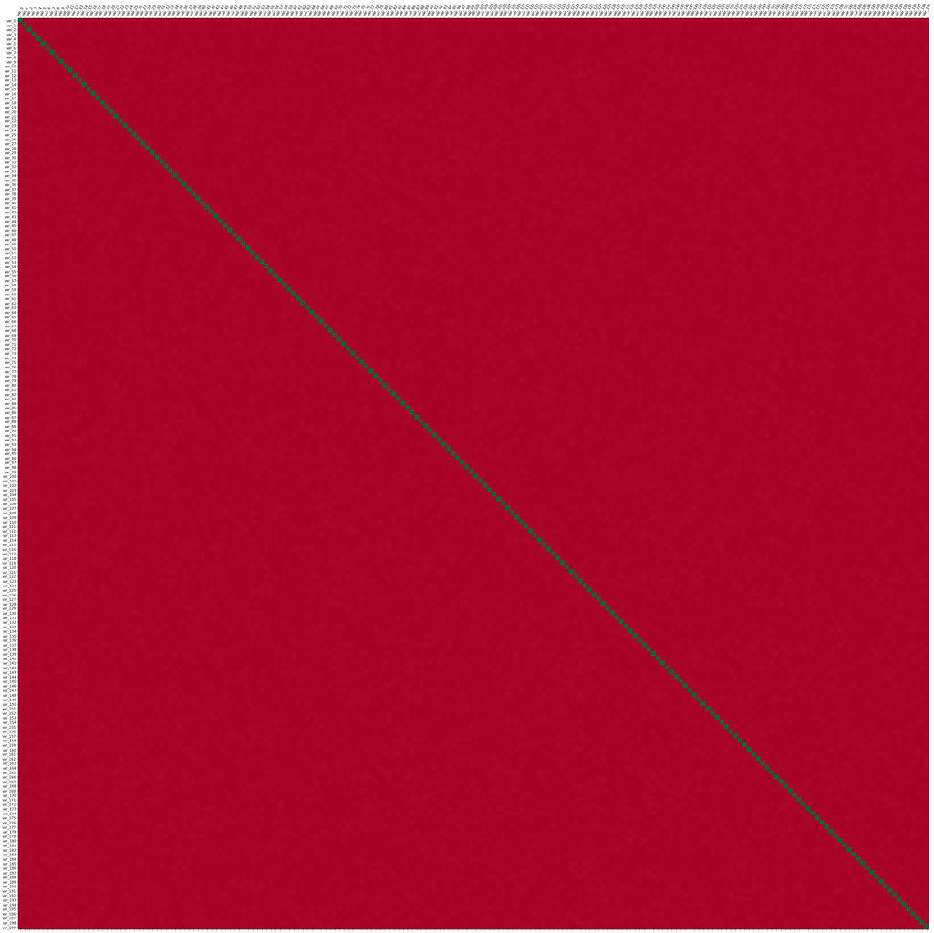

```python
corr = DF.corr()
#print(corr)

#plt.matshow(corr)

labels = [c[:8] for c in corr.columns]  # get var names.

fig = plt.figure(figsize=(50,50))  # figure so we can add axis
ax = fig.add_subplot(111)  # define axis, so we can modify
ax.matshow(corr, cmap=plt.cm.RdYlGn)  # display the matrix
ax.set_xticks(np.arange(len(labels)))  # show them all!
ax.set_yticks(np.arange(len(labels)))  # show them all!
ax.set_xticklabels(labels)  # set to be the var tick labels
ax.set_yticklabels(labels)  # set to be the var tick labels

for tick in ax.get_xticklabels():
    tick.set_rotation(60)

plt.show()
```

As we can see from the above correlation graph, aside from comparing a variable column to itself in the diagonal, it does not seem that the variable columns have much correlation between one another, if any at all. Therefore, we cannot make decisions based on the result of corr().

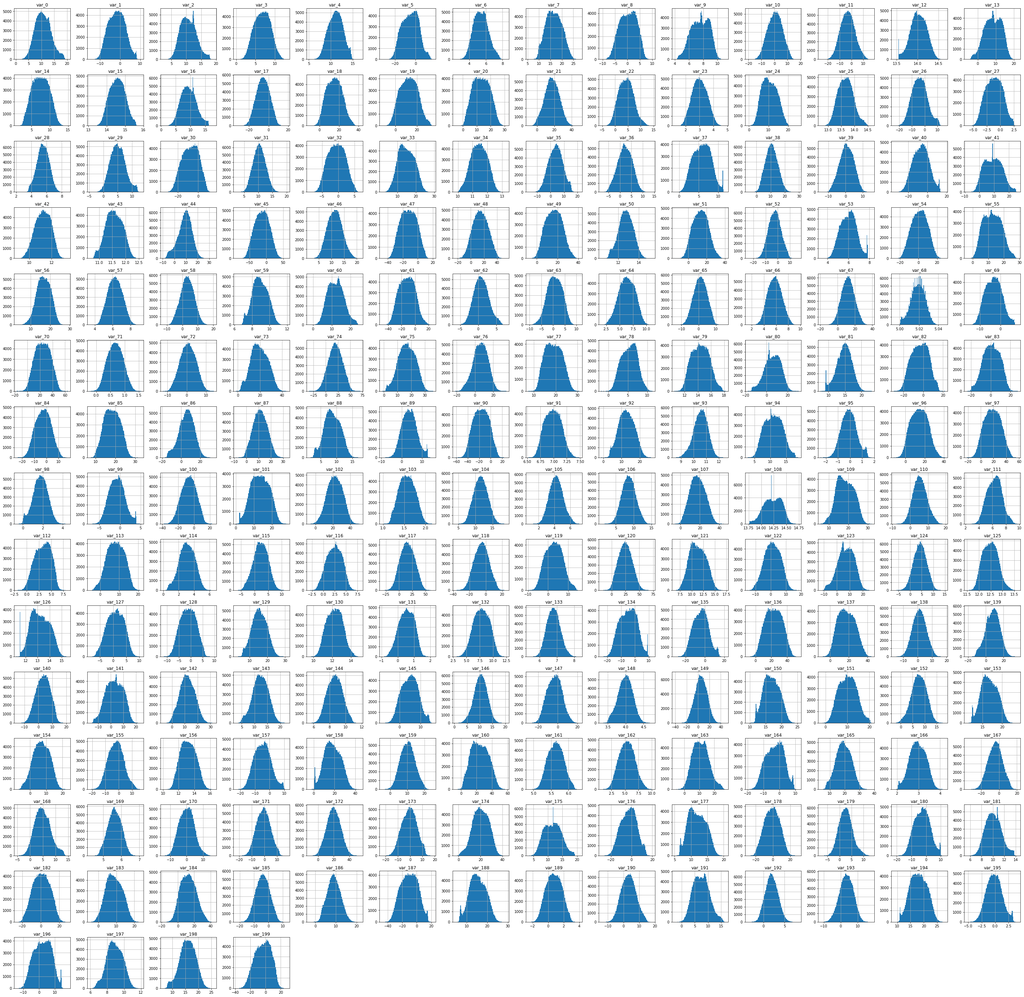

```python
DF.hist(bins=100, figsize=(50,50))
plt.show()
```

Graphed histograms of all the variables. For the most part, this doesn't tell me anything, other than that within their individual ranges, pretty much all of the variables are mostly normally distributed.

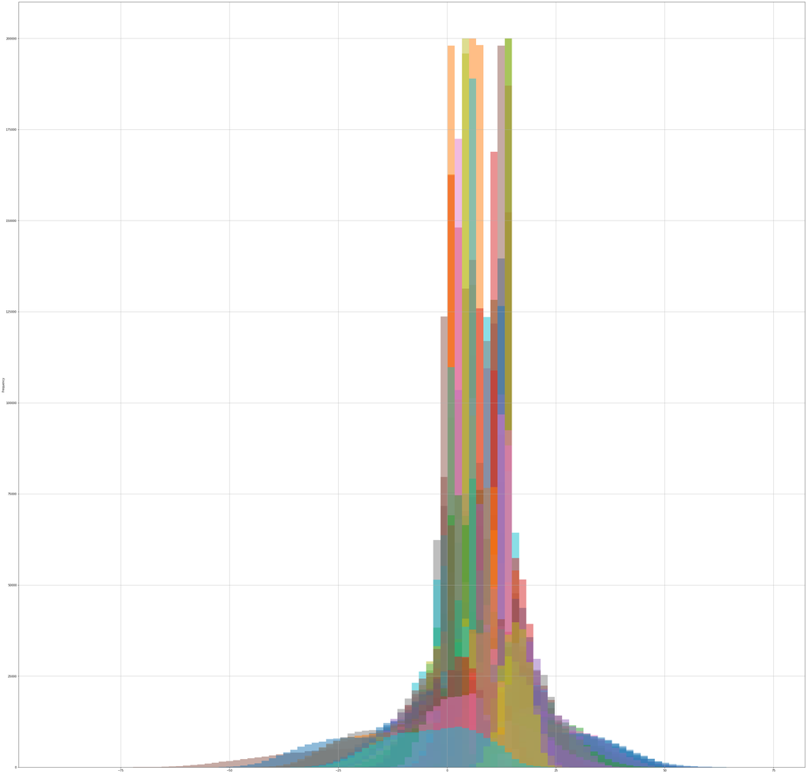

```python
DF.plot.hist(bins=100, figsize=(50,50), alpha = 0.5, grid=True, legend=False)
plt.show()
```

By creating a new histogram by overlaying all of the histograms on top of each other, we can see that the vast majority of the data seems to fall between the range (-25, 25)

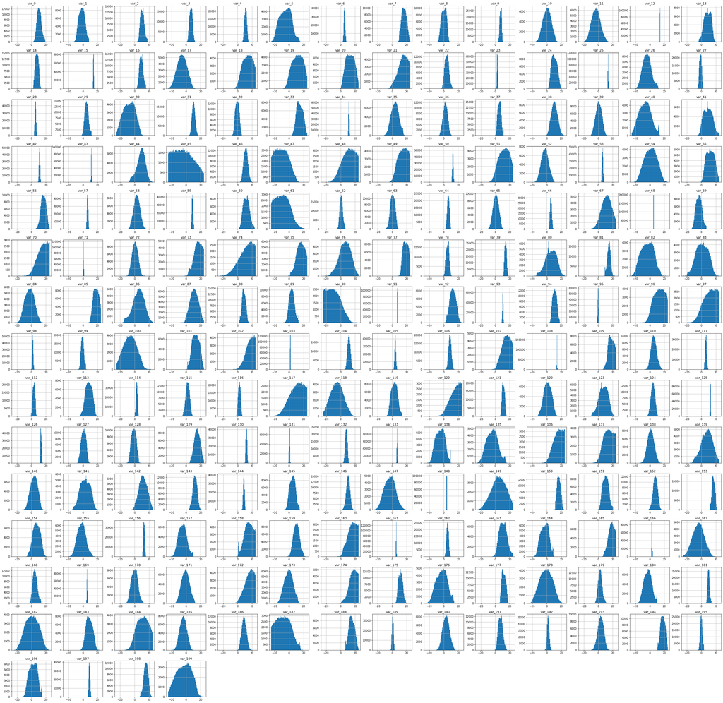

```python
DF.hist(bins=100, figsize=(50,50), range=(-25,25))
plt.show()
```

From the above graphs, we can determine that some of the variables have an extremely low standard deviation/variance, and some of the variables have an extremely high deviation.

## Feature Engineering

Based on our exploratory data analysis from before, since there is no inherent correlation between any of the initial Dataframe features, I have decided to drop features based on whether or not the rounded means and standard deviations are identical.

To achieve this, I will round the means and standard deviations, take the transpose of that matrix, drop identical/duplicate rows, and then retranspose it back.

```python
from sklearn import preprocessing
min_max = preprocessing.MinMaxScaler()

#newDF = DF.drop('ID_code',axis=1)
newDF = pd.DataFrame(DF.describe().iloc[1:3])
roundDF = np.round(newDF)

roundDFT = roundDF.T
roundDFT = roundDFT.drop_duplicates()
roundDF = roundDFT.T
print(roundDF)
roundDF.shape
```

```
      var_0  var_1  var_3  var_4  var_5  var_6  var_7  var_8  var_9  var_10  \
mean   11.0   -2.0    7.0   11.0   -5.0    5.0   17.0    0.0    8.0     0.0
std     3.0    4.0    2.0    2.0    8.0    1.0    3.0    3.0    1.0     6.0

      var_11  var_12  var_13  var_14  var_15  var_16  var_17  var_18  var_19  \
mean    -3.0    14.0     9.0     8.0    15.0     9.0    -6.0    15.0    12.0
std      6.0     0.0     5.0     2.0     0.0     3.0     7.0     8.0     8.0

      var_20  var_21  var_22  var_23  var_24  var_26  var_27  var_28  var_29  \
mean    13.0    17.0     4.0     3.0    11.0    -4.0    -1.0     6.0     5.0
std      6.0     8.0     3.0     1.0     4.0     6.0     2.0     1.0     3.0

      var_30  var_31  var_32  var_33  var_34  var_35  var_36  var_37  var_39  \
mean    -8.0    10.0    -1.0    15.0    11.0     4.0     2.0     6.0     1.0
std      8.0     2.0     3.0     4.0     1.0     5.0     3.0     2.0     4.0

      var_40  var_41  var_43  var_45  var_47  var_48  var_50  var_51  var_52  \
mean    -7.0     9.0    12.0   -13.0   -12.0    15.0    13.0    13.0    -3.0
std      8.0     6.0     0.0    21.0    11.0    11.0     1.0     8.0     5.0

      var_54  var_56  var_58  var_59  var_60  var_61  var_62  var_63  var_67  \
mean     1.0    17.0     3.0     9.0    12.0   -12.0     1.0     1.0    12.0
std      8.0     4.0     4.0     1.0     4.0    12.0     2.0     3.0     7.0

      var_68  var_69  var_70  var_71  var_73  var_74  var_75  var_76  var_77  \
mean     5.0    -3.0    24.0     1.0    20.0    20.0    17.0     6.0    19.0
std      0.0     4.0    12.0     0.0     7.0    14.0     6.0     8.0     4.0

      var_78  var_79  var_80  var_81  var_82  var_85  var_87  var_88  var_89  \
mean     5.0    14.0     6.0    15.0    -3.0    18.0    11.0     9.0     4.0
std      2.0     1.0     7.0     2.0     8.0     4.0     6.0     2.0     4.0

      var_90  var_91  var_92  var_95  var_96  var_97  var_98  var_100  \
mean   -17.0     7.0    13.0    -0.0    14.0    19.0     2.0     -7.0
std     13.0     0.0     4.0     1.0     9.0    13.0     1.0      9.0

      var_101  var_102  var_103  var_104  var_105  var_107  var_110  var_112  \
mean     13.0     22.0      2.0     12.0      4.0     18.0      6.0      3.0
std       5.0      9.0      0.0      2.0      1.0      8.0      4.0      2.0

```

[output cut: 12 more lines]

```
      var_152  var_154  var_155  var_160  var_161  var_163  var_165  var_166  \
mean      8.0      7.0     -2.0     24.0      6.0     11.0     19.0      3.0
std       3.0      5.0      6.0     11.0      0.0      5.0      5.0      0.0

      var_170  var_171  var_172  var_173  var_178  var_179  var_181  var_182  \
mean     -0.0     -1.0     20.0     -1.0     -1.0      3.0     10.0      1.0
std       4.0      5.0      9.0      6.0      9.0      3.0      1.0      9.0

      var_183  var_184  var_185  var_187  var_189  var_191  var_194  var_196  \
mean      9.0     13.0     -4.0    -10.0      1.0      7.0     18.0      2.0
std       4.0      9.0      5.0     12.0      1.0      3.0      3.0      5.0

      var_198  var_199
mean     16.0     -3.0
std       3.0     10.0
```

```
(2, 139)
```

After I get the secondary dataframe with the variables that will remain in the Dataframe, I loop through the Dataframe and remove all the duplicate features that will be removed.

```python
#roundDF.columns[2]

#count = 0

removedDF = DF
#print(removedDF)
for x in DF.columns:
    if((x in roundDF.columns) == False):
        removedDF = removedDF.drop([x], axis='columns')

print(removedDF)
```

```
          var_0   var_1   var_3    var_4    var_5   var_6    var_7   var_8  \
0        8.9255 -6.7863  5.0930  11.4607  -9.2834  5.1187  18.6266 -4.9200
1       11.5006 -4.1473  5.3890  12.3622   7.0433  5.6208  16.5338  3.1468
2        8.6093 -2.7457  7.8928  10.5825  -9.0837  6.9427  14.6155 -4.9193
3       11.0604 -2.1518  7.1957  12.5846  -1.8361  5.8428  14.9250 -5.8609
4        9.8369 -1.4834  6.6375  12.2772   2.4486  5.9405  19.2514  6.2654
...         ...     ...     ...      ...      ...     ...      ...     ...
199995  11.4880 -0.4956  3.5142  10.3404  11.6081  5.6709  15.1516 -0.6209
199996   4.9149 -2.4484  6.6345   8.3096 -10.5628  5.8802  21.5940 -3.6797
199997  11.2232 -5.0518  5.6456   9.3410  -5.4086  4.5555  21.5571  0.1202
199998   9.7148 -8.6098  5.7930  12.5173   0.5339  6.0479  17.0152 -2.1926
199999  10.8762 -5.7105  8.0328  11.5577   0.3488  5.2839  15.2058 -0.4541

         var_9  var_10   var_11   var_12   var_13   var_14   var_15   var_16  \
0       5.7470  2.9252   3.1821  14.0137   0.5745   8.7989  14.5691   5.7487
```

[output cut: 233 more lines]

Upon completing this, I now have a new dataframe removedDF that has duplicate values removed. By doing this, we have reduced the number of features from 200 to 139, a 30% improvement.

## Clustering

```python
from sklearn.cluster import KMeans
kmeans=KMeans()
```

The next thing we will do is to use the elbow plot method to determine the ideal number of clusters for our clustering.

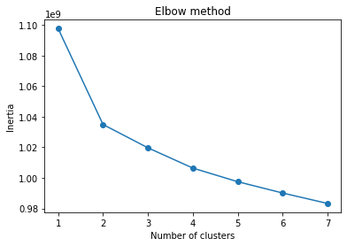

```python
def plot_inertia(km, X, n_cluster_range):
    inertias = []
    for i in n_cluster_range:
        km.set_params(n_clusters=i)
        km.fit(X)
        inertias.append(km.inertia_)
    plt.plot(n_cluster_range, inertias, marker='o')
    plt.title('Elbow method')
    plt.xlabel('Number of clusters')
    plt.ylabel('Inertia')
    plt.show()

plot_inertia(kmeans,removedDF, range(1,8))
```

As shown above, it would seem that 2 clusters would be a pretty reasonable pick for the kmeans cluster count.

We will then perform the kmeans fitting on the data.

```python
kmeans.set_params(n_clusters=2)
kmeans.fit(removedDF)
```

```
KMeans(n_clusters=2)
```

```python
kmeans.labels_
```

```
array([0, 1, 0, ..., 1, 1, 0], dtype=int32)
```

```python
kmeans.cluster_centers_
```

```
array([[ 1.06735329e+01, -1.63667798e+00,  6.79687152e+00,
         1.10735975e+01, -5.07337193e+00,  5.40652655e+00,
         1.65386697e+01,  2.89311891e-01,  7.56589801e+00,
         3.90309205e-01, -3.25163732e+00,  1.40235851e+01,
         8.54267617e+00,  7.53344562e+00,  1.45723093e+01,
         9.33425131e+00, -5.70688366e+00,  1.52671486e+01,
         1.24270415e+01,  1.32781197e+01,  1.72829814e+01,
         4.30397332e+00,  3.02026918e+00,  1.05822826e+01,
        -4.07072446e+00, -1.14051924e+00,  5.53346988e+00,
         5.05247631e+00, -7.71557346e+00,  1.03861615e+01,
        -5.19680654e-01,  1.47713824e+01,  1.14346077e+01,
         3.84321938e+00,  2.18866770e+00,  5.87311122e+00,
         6.75085966e-01, -6.76290820e+00,  9.29468870e+00,
         1.15708305e+01,  4.82692029e+00, -1.24629587e+01,
         1.46531500e+01,  1.27437040e+01,  1.33978307e+01,
        -2.53813283e+00,  1.10932083e+00,  1.66482236e+01,
         3.16864903e+00,  8.93100638e+00,  1.21488248e+01,
        -1.19459852e+01,  8.69795842e-01,  6.64860738e-01,
         1.19202535e+01,  5.01893565e+00, -3.33237237e+00,
         2.44344646e+01,  6.69094560e-01,  1.96454086e+01,
         1.95153470e+01,  1.68541798e+01,  6.05345289e+00,
         1.90783862e+01,  5.34356552e+00,  1.44012111e+01,
         5.75425517e+00,  1.47194266e+01, -3.47010005e+00,
         1.83553155e+01,  1.13491907e+01,  8.70416265e+00,
         3.72240250e+00, -1.65906331e+01,  6.98722011e+00,
         1.27303698e+01, -8.36975684e-02,  1.44004832e+01,
         1.85737803e+01,  1.74877114e+00, -6.58304988e+00,
         1.34089789e+01,  2.23348738e+01,  1.56830466e+00,
         1.15136079e+01,  4.24305848e+00,  1.77940969e+01,
         5.49443349e+00,  3.32068918e+00,  8.12985323e+00,
         2.40591426e+00,  1.61116586e+01, -5.32608785e+00,
         2.45088197e+01,  1.19579899e+00,  7.08948590e+00,
         1.22582562e+01, -4.85075344e+00, -4.25825865e+00,
         2.29957955e+01,  1.76059484e+01,  7.74905094e+00,
         3.41984358e+00,  2.85711726e+00,  1.19762248e+01,
         1.23351311e+01,  4.84868074e+00,  1.03381770e+01,
        -3.29887242e+00,  3.99123963e+00,  5.38008599e+00,
         1.68138493e+01,  1.01567807e+01,  7.62663723e+00,
         6.94404592e+00, -2.06760960e+00,  2.42703415e+01,
         5.63309034e+00,  1.09957601e+01,  1.92980910e+01,
```

[output cut: 39 more lines]

```
         1.22560223e+01, -4.80083045e+00, -4.26071128e+00,
         2.29408339e+01,  1.76215168e+01,  7.77157073e+00,
         3.42750930e+00,  2.93892930e+00,  1.19909056e+01,
         1.23322347e+01,  4.83381916e+00,  1.03442421e+01,
        -3.30272609e+00,  3.99020086e+00,  5.21061821e+00,
         1.68215738e+01,  1.01259808e+01,  7.63989922e+00,
         7.00651594e+00, -2.08078358e+00,  2.42480257e+01,
         5.63349899e+00,  1.10087144e+01,  1.93337881e+01,
         2.96351474e+00, -8.82841768e-03, -8.41460258e-01,
         1.98229512e+01, -6.88686017e-01, -1.01106476e+00,
         2.59908820e+00,  1.00839234e+01,  7.23419793e-01,
         8.75012341e+00,  1.27216909e+01, -3.97981333e+00,
        -1.03311360e+01,  7.45236406e-01,  7.42758495e+00,
         1.79823318e+01,  2.31658535e+00,  1.58637748e+01,
        -3.28940843e+00]])
```

After performing the clustering analysis, we do some discrete mathematics

```python
removedDFStats = (pd.DataFrame(removedDF, columns = removedDF.columns)).describe()
clusterStats = (pd.DataFrame(kmeans.cluster_centers_, columns = removedDF.columns)).describe()
clusterDF = (pd.DataFrame(kmeans.cluster_centers_, columns = removedDF.columns))
#print(removedDFStats)
print(clusterStats)
#print(clusterDF)
```

```
           var_0     var_1     var_3      var_4     var_5     var_6  \
count   2.000000  2.000000  2.000000   2.000000  2.000000  2.000000
mean   10.679982 -1.627526  6.796526  11.078383 -5.065233  5.408974
std     0.009120  0.012943  0.000489   0.006768  0.011511  0.003462
min    10.673533 -1.636678  6.796180  11.073598 -5.073372  5.406527
25%    10.676757 -1.632102  6.796353  11.075990 -5.069302  5.407750
50%    10.679982 -1.627526  6.796526  11.078383 -5.065233  5.408974
75%    10.683206 -1.622950  6.796699  11.080776 -5.061163  5.410198
max    10.686430 -1.618374  6.796872  11.083169 -5.057093  5.411422

           var_7     var_8     var_9    var_10    var_11     var_12    var_13  \
count   2.000000  2.000000  2.000000  2.000000  2.000000   2.000000  2.000000
mean   16.545926  0.284108  7.567250  0.394383 -3.245532  14.023982  8.530101
std     0.010261  0.007360  0.001913  0.005761  0.008634   0.000561  0.017784
min    16.538670  0.278903  7.565898  0.390309 -3.251637  14.023585  8.517526
25%    16.542298  0.281505  7.566574  0.392346 -3.248585  14.023784  8.523814
50%    16.545926  0.284108  7.567250  0.394383 -3.245532  14.023982  8.530101
75%    16.549554  0.286710  7.567927  0.396420 -3.242480  14.024180  8.536389
max    16.553182  0.289312  7.568603  0.398457 -3.239427  14.024379  8.542676

         var_14     var_15    var_16    var_17     var_18     var_19  \
count  2.000000   2.000000  2.000000  2.000000   2.000000   2.000000
mean   7.537650  14.573134  9.333254 -5.696624  15.243769  12.438689
std    0.005946   0.001167  0.001411  0.014510   0.033064   0.016472
min    7.533446  14.572309  9.332256 -5.706884  15.220389  12.427042
25%    7.535548  14.572722  9.332755 -5.701754  15.232079  12.432865
50%    7.537650  14.573134  9.333254 -5.696624  15.243769  12.438689
75%    7.539752  14.573547  9.333753 -5.691494  15.255459  12.444513
max    7.541854  14.573960  9.334251 -5.686364  15.267149  12.450336

          var_20     var_21    var_22    var_23     var_24    var_26  \
count   2.000000   2.000000  2.000000  2.000000   2.000000  2.000000
mean   13.291029  17.257618  4.305446  3.019532  10.584422 -4.054969
std     0.018256   0.035869  0.002082  0.001042   0.003026  0.022282
min    13.278120  17.232255  4.303973  3.018795  10.582283 -4.070724
25%    13.284574  17.244936  4.304710  3.019164  10.583352 -4.062847
50%    13.291029  17.257618  4.305446  3.019532  10.584422 -4.054969
75%    13.297483  17.270300  4.306182  3.019901  10.585492 -4.047091
max    13.303938  17.282981  4.306918  3.020269  10.586562 -4.039213

```

[output cut: 174 more lines]

```
min   -3.986637 -10.338868  0.745236  7.427585  17.982332  2.290359
25%   -3.984931 -10.336935  0.745650  7.432941  17.987999  2.296916
50%   -3.983225 -10.335002  0.746063  7.438297  17.993666  2.303472
75%   -3.981519 -10.333069  0.746476  7.443652  17.999333  2.310029
max   -3.979813 -10.331136  0.746890  7.449008  18.005000  2.316585

         var_198   var_199
count   2.000000  2.000000
mean   15.870648 -3.326153
std     0.009721  0.051965
min    15.863775 -3.362898
25%    15.867212 -3.344526
50%    15.870648 -3.326153
75%    15.874085 -3.307781
max    15.877522 -3.289408
```

From each of the clusters, we can further trim down our data by removing features that have the same rounded std and means, similar to before. By doing this, we get rid of potentially redundant features.

```python
meanstdClusterStats = clusterStats.iloc[1:3]
roundCluster = np.round(meanstdClusterStats, 1)
print(roundCluster)
print(roundCluster.shape)
roundCluster = roundCluster.T
roundCluster = roundCluster.drop_duplicates()
roundCluster = roundCluster.T
print('---------------------------')
print(roundCluster)
print(roundCluster.shape)
```

```
      var_0  var_1  var_3  var_4  var_5  var_6  var_7  var_8  var_9  var_10  \
mean   10.7   -1.6    6.8   11.1   -5.1    5.4   16.5    0.3    7.6     0.4
std     0.0    0.0    0.0    0.0    0.0    0.0    0.0    0.0    0.0     0.0

      var_11  var_12  var_13  var_14  var_15  var_16  var_17  var_18  var_19  \
mean    -3.2    14.0     8.5     7.5    14.6     9.3    -5.7    15.2    12.4
std      0.0     0.0     0.0     0.0     0.0     0.0     0.0     0.0     0.0

      var_20  var_21  var_22  var_23  var_24  var_26  var_27  var_28  var_29  \
mean    13.3    17.3     4.3     3.0    10.6    -4.1    -1.1     5.5     5.1
std      0.0     0.0     0.0     0.0     0.0     0.0     0.0     0.0     0.0

      var_30  var_31  var_32  var_33  var_34  var_35  var_36  var_37  var_39  \
mean    -7.7    10.4    -0.5    14.8    11.4     3.8     2.2     5.9     0.7
std      0.0     0.0     0.0     0.0     0.0     0.0     0.0     0.0     0.0

      var_40  var_41  var_43  var_45  var_47  var_48  var_50  var_51  var_52  \
mean    -6.7     9.3    11.6   -12.9   -12.5    14.7    12.7    13.4    -2.5
std      0.1     0.0     0.0    25.0     0.0     0.1     0.0     0.0     0.0

      var_54  var_56  var_58  var_59  var_60  var_61  var_62  var_63  var_67  \
mean     1.1    16.6     3.2     8.9    12.2   -11.9     0.9     0.7    11.9
std      0.0     0.0     0.0     0.0     0.0     0.0     0.0     0.0     0.0

      var_68  var_69  var_70  var_71  var_73  var_74  var_75  var_76  var_77  \
mean     5.0    -3.3    24.4     0.7    19.6    19.5    16.9     6.1    19.1
std      0.0     0.0     0.0     0.0     0.0     0.0     0.0     0.0     0.0

      var_78  var_79  var_80  var_81  var_82  var_85  var_87  var_88  var_89  \
mean     5.3    14.4     5.8    14.7    -3.5    18.4    11.4     8.7     3.7
std      0.0     0.0     0.1     0.0     0.0     0.0     0.0     0.0     0.0

      var_90  var_91  var_92  var_95  var_96  var_97  var_98  var_100  \
mean   -16.5     7.0    12.7    -0.1    14.4    18.5     1.8     -6.6
std      0.1     0.0     0.0     0.0     0.0     0.0     0.0      0.0

      var_101  var_102  var_103  var_104  var_105  var_107  var_110  var_112  \
mean     13.4     22.3      1.6     11.5      4.2     17.8      5.5      3.3
std       0.0      0.1      0.0      0.0      0.0      0.0      0.0      0.0

```

[output cut: 74 more lines]

```
mean      4.8     10.3      4.0      5.3     16.8     10.1     -2.1     24.3
std       0.0      0.0      0.0      0.1      0.0      0.0      0.0      0.0

      var_161  var_163  var_165  var_170  var_171  var_172  var_173  var_178  \
mean      5.6     11.0     19.3     -0.0     -0.8     19.8     -0.7     -1.0
std       0.0      0.0      0.0      0.0      0.0      0.0      0.0      0.0

      var_179  var_183  var_184  var_185  var_187  var_191  var_194  var_196  \
mean      2.6      8.8     12.8     -4.0    -10.3      7.4     18.0      2.3
std       0.0      0.0      0.0      0.0      0.0      0.0      0.0      0.0

      var_198  var_199
mean     15.9     -3.3
std       0.0      0.1
(2, 123)
```

```python
removedClusterDF = removedDF

for x in removedClusterDF:
    if((x in roundCluster.columns) == False):
        removedClusterDF = removedClusterDF.drop([x], axis='columns')

print(removedClusterDF)
```

```
          var_0   var_1   var_3    var_4    var_5   var_6    var_7   var_8  \
0        8.9255 -6.7863  5.0930  11.4607  -9.2834  5.1187  18.6266 -4.9200
1       11.5006 -4.1473  5.3890  12.3622   7.0433  5.6208  16.5338  3.1468
2        8.6093 -2.7457  7.8928  10.5825  -9.0837  6.9427  14.6155 -4.9193
3       11.0604 -2.1518  7.1957  12.5846  -1.8361  5.8428  14.9250 -5.8609
4        9.8369 -1.4834  6.6375  12.2772   2.4486  5.9405  19.2514  6.2654
...         ...     ...     ...      ...      ...     ...      ...     ...
199995  11.4880 -0.4956  3.5142  10.3404  11.6081  5.6709  15.1516 -0.6209
199996   4.9149 -2.4484  6.6345   8.3096 -10.5628  5.8802  21.5940 -3.6797
199997  11.2232 -5.0518  5.6456   9.3410  -5.4086  4.5555  21.5571  0.1202
199998   9.7148 -8.6098  5.7930  12.5173   0.5339  6.0479  17.0152 -2.1926
199999  10.8762 -5.7105  8.0328  11.5577   0.3488  5.2839  15.2058 -0.4541

         var_9  var_10   var_11   var_12   var_13   var_14   var_15   var_16  \
0       5.7470  2.9252   3.1821  14.0137   0.5745   8.7989  14.5691   5.7487
```

[output cut: 194 more lines]

Now, through observing similarities between clustering observations, we have now reduced our features down to 123 columns.

## PCA

```python
from sklearn.decomposition import PCA
from sklearn.preprocessing import StandardScaler

features = removedClusterDF.columns
x = removedClusterDF.loc[:, features]
x = StandardScaler().fit_transform(x) # normalizing the features

print(np.mean(x)) # Should be about 0
print(np.std(x)) # Should be about 1

pca = PCA(.95)
principalComponents = pca.fit(x)
#principalDf = pd.DataFrame(data = principalComponents)
#principalDf
```

```
-1.7454944445563615e-15
1.0000000000000004
```

```python
pca.explained_variance_ratio_
```

```
array([0.00925154, 0.00851504, 0.00851294, 0.00848997, 0.00847112,
       0.00846343, 0.00845897, 0.00844729, 0.00843661, 0.00842679,
       0.00841906, 0.00841312, 0.0083992 , 0.0083957 , 0.0083922 ,
       0.00838414, 0.00836924, 0.00836401, 0.00835554, 0.00834819,
       0.00834503, 0.00833748, 0.00833375, 0.00833105, 0.00832344,
       0.0083171 , 0.0083133 , 0.0082995 , 0.00829787, 0.00829195,
       0.00828054, 0.00827733, 0.00827368, 0.00826949, 0.00826654,
       0.00825486, 0.00825236, 0.00824287, 0.00824056, 0.00823568,
       0.00823212, 0.00822728, 0.0082239 , 0.00822135, 0.00821141,
       0.00820338, 0.00820026, 0.00819706, 0.00819055, 0.00818087,
       0.00817577, 0.00817187, 0.00816445, 0.00816099, 0.00815824,
       0.00815224, 0.00814677, 0.00813666, 0.00813169, 0.00813001,
       0.00812476, 0.00812042, 0.00811569, 0.00810743, 0.00810435,
       0.00809487, 0.00809424, 0.00809256, 0.00808282, 0.00807785,
       0.00807438, 0.00807138, 0.00806339, 0.0080557 , 0.00805236,
       0.00804989, 0.00804482, 0.00803813, 0.00803   , 0.00802785,
       0.00802104, 0.00801587, 0.00801521, 0.00800596, 0.00800094,
       0.00799824, 0.00799337, 0.00798974, 0.00798506, 0.00797656,
       0.00797593, 0.00797056, 0.00796078, 0.00795564, 0.00794623,
       0.00794257, 0.00793323, 0.00792857, 0.00792474, 0.00791715,
       0.00791081, 0.00790764, 0.00789975, 0.00789659, 0.00789274,
       0.00788232, 0.00787687, 0.00787546, 0.00786866, 0.00786311,
       0.00784977, 0.00784425, 0.00783407, 0.00782698, 0.00781843,
       0.0078126 , 0.00781161])
```

The first principal component contains 0.93% of the variance and the second principal component contains .85% of the variance.

```python
pca.n_components_
```

```
117
```

In order to retain 95% of the data, we can reduce the dimensions down to 117 principal components.